# AS6-2

第19組

2019-04-02 02:01:00

### 改寫Faith.R

```r
# read data
D = faithful$waiting
summary(D) #由summary得知最小43，最大96
```

```
   Min. 1st Qu.  Median    Mean 3rd Qu.    Max.
   43.0    58.0    76.0    70.9    82.0    96.0
```

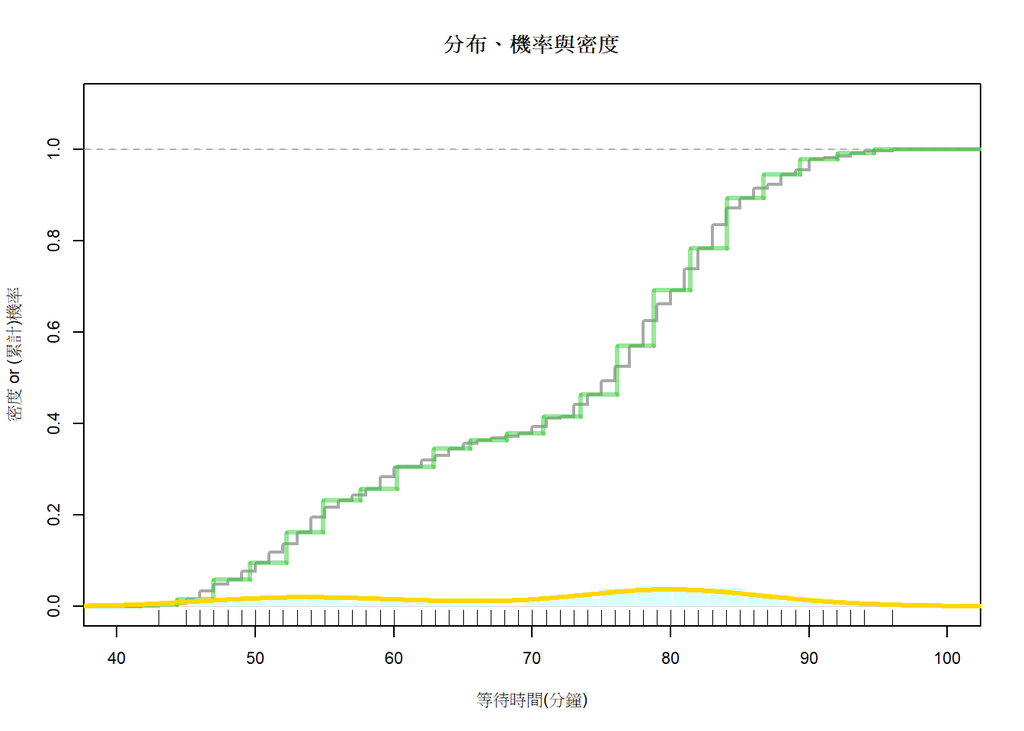

```r
# Frame
par(cex = 0.7)
plot(0, 0, xlim = c(40, 100), ylim = c(0, 1.1), xlab = "等待時間(分鐘)",
     ylab = "密度 or (累計)機率", main = "分布、機率與密度")
abline(h = 1, col = 'lightgray', lwd = 0.25, lty = 2)

# Empirical PDF   #x軸的標記線表示事件發生
rug(D)

# Empirical CDF
plot(ecdf(D), cex=0, verticals=T, lwd=2, col='darkgray', add=T)

# Histogram PDF
Bins=20       #欄位數(no. bins)
bx = seq(min(D), max(D), length=Bins+1) # break sequence 21條bins才會有20欄
hist(D, col="#B3FFFF7F", border="white", ylim=c(0,1.1),
     freq=F, breaks=bx, add=T)
abline(h=0, col='lightgray', lwd=0.25)

# Histogram CDF
adj = (bx[2] - bx[1])/2
steps = stepfun(bx-adj, c(0, sapply(bx, function(b) mean(D <= b))))
plot(steps, cex=0, col='#33CC337F', lwd=3, lty=1, add=T)

# Smooth PDF
Adjust =1    # bandwidth adjustment
DEN = density(D, adjust = Adjust)
lines(DEN, col='gold', lwd=3)

# Smooth CDF
PDF = approxfun(DEN$x, DEN$y, yleft=0, yright=0)
x = seq(4.2,9.7,1)
y = sapply(x, function(i) integrate(PDF, -Inf, i)$value)
lines(x, y, col='red', lwd=3, lty=2)

# Mark Range
x1 = 8.0; x2 = 9.0
rect(x1,-0.1,x2,1.2,col= rgb(0,1,0,alpha=0.2),border=NA)
```

```r
# x = seq(x1, x2, length=100)
# polygon(c(x, x2, x1),  c(PDF(x), 0, 0), col="#FF99003F", border=NA)
# Calculate Probability
(integrate(PDF, x1, x2)$value)
```

```
[1] 0
```

### 【A.選擇方法】

■ 我們為甚麼需要隨機變數？ 什麼時候我們需要用到隨機變數？  
Ans:1. 隨機試驗的種類多而且複雜, 如果我們將一大堆的試驗結果經過隨機變數處理，將其轉換為數值, 方便我們用來做數學分析。  
2. 當隨機試驗的種類多而且複雜的時候需要用到隨機變數。  
■ 隨機變數沒有固定的值，那我們要如何做計算呢？  
Ans:可以計算其分配並拿來求期望值、變異數等等，也可以拿來、推導母體、進行各種分析  
■ 我們可以用直方圖或數值標記來估計噴發時間落在某一區間的機率嗎？  
Ans:1. 可以用直方圖。（因為直方圖是連續的，所以可以設定某一個值到另一個值之間的直方圖面積來計算機率。）  
2. 不能用數值標記。（數值標記只是標註數字，無法計算機率。）  
■ 直方圖(histogram)也可以當作一種模型嗎？ 數值標記(rug)呢？  
Ans:1. 直方圖：知道他的機率分佈時，就可以當作模型。（知道一個點之後就可以了解它的分布，所以可以當作模型。）  
2. 數值標記：不能當作一個模型。因為數值標記只是最簡單用來記錄的一種方法。  
■ 直方圖和平滑模型哪一個比較適合用來表示噴發時間的分布？ 為甚麼？  
Ans:平滑模型。因為平滑模型是一個連續性的模型，時間也是一個連續性的概念，所以平滑模型比較適合表示噴發時間的分佈。  
雖然直方圖也是連續性的圖表，除非把單位切到最小，否則要計算連續性時間的概念的話，可能有誤差  
■ 用數值標記來預測噴發時間會比用直方圖「準」嗎？ 「準」是什麼意思呢？  
Ans:1. 數值標記不會比較準確。因為數值標記中不會找到機率。  
（例如你這次考100分，就算你標記起來，你也沒辦法預測你下次會不會考100分）  
2. 「你所猜的結果最接近最後的結果」，就是所謂「準」。

### 【B.調整參數】

調整一下模型參數的滑桿 …  
■ 你覺得最合適的直方圖欄數(`support/binwidth`)是？ 為甚麼？  
Ans:1. 16。  
2. 因為如果太小的話，沒辦法看出趨勢;如果數值太大的話，會出現一個太突出的區間，造成無法符合平滑曲線的狀況。  
■ 最合適的平滑模型頻寬(`bandwidth`)呢？  
Ans:1. 0.5。  
2. 因為如果數值太小，平滑模型的線會太突出，造成和趨勢不符合;如果數值太大，則造成平滑模型的線太平，看不出趨勢。  
■ 調高欄寬和頻寬會讓模型變複雜，還是變簡單呢？  
Ans:調高欄寬和頻寬都會讓模型變簡單。  
■ 模型越複雜，它跟實際值之間的誤差是越大、還是越小？  
Ans:通常模型越複雜，跟訓練資料之間的誤差就越小，但模型太複雜會失去一般性，而不能準確估計訓練資料以外的對象  
■ 那麼，越複雜的模型就會越準，對嗎？  
Ans:預測＂訓練資料＂就會越準;測樣本以外的資料的時候，它的準確性就會變差

### 【C.建立模型、估計機率】

請從課堂筆記的程式碼找出來 …  
■ 從變數向量(`D`)求出機率密度曲線(`DEN`)

```
Adjust = 1    # bandwidth adjustment
DEN = density(D, adjust = Adjust)
lines(DEN, col='gold', lwd=3)
```

■ 將機率密度曲線(`DEN`)轉換成機率密度函數(`PDF`)

```
PDF = approxfun(DEN$x, DEN$y, yleft=0, yright=0)
```

■ 對機率密度函數(`PDF`)做積分，算出機率(`PROB`)

```
integrate(PDF, x1, y1)$value
```

這三行程式，然後…  
■ 將頻寬調整參數(`adjust`)設為`1`，算出「等待時間」落在80到90之間的機率  
Ans:機率為0.2685

```r
Adjust = 1
DEN = density(D, adjust = Adjust)
PDF = approxfun(DEN$x, DEN$y, yleft=0, yright=0)
(integrate(PDF, 80, 90)$value)
```

```
[1] 0.26851
```

■ 將頻寬調整參數設為`0.5`，算出等待時間落在80到90之間的機率  
Ans:機率為0.2827451

```r
Adjust = 0.5
DEN = density(D, adjust = Adjust)
PDF = approxfun(DEN$x, DEN$y, yleft=0, yright=0)
(integrate(PDF, 80, 90)$value)
```

```
[1] 0.28275
```

■ 算出來的機率比較高的就是比較好的模型，對嗎？ 為甚麼？  
Ans:不一定，頻寬越小模型就會越複雜，但是若太高的話反而會過度適配

### 【D.預測與決策】

假設有一個賭局，你可以花30元選定一個連續60秒的時段，如果老忠實下一次的噴發時間落在你指定的區間，你就可以贏到100元；請你使用頻寬為`0.5`的平滑密度模型 …  
■ 決定要不要參加這個賭局  
Ans:要  
■ 如果你參加的話，你要把噴發時間設定在哪一個區間呢？  
Ans:以下圖為例，3.9 ~ 4.9分間

```r
library(dplyr)
```

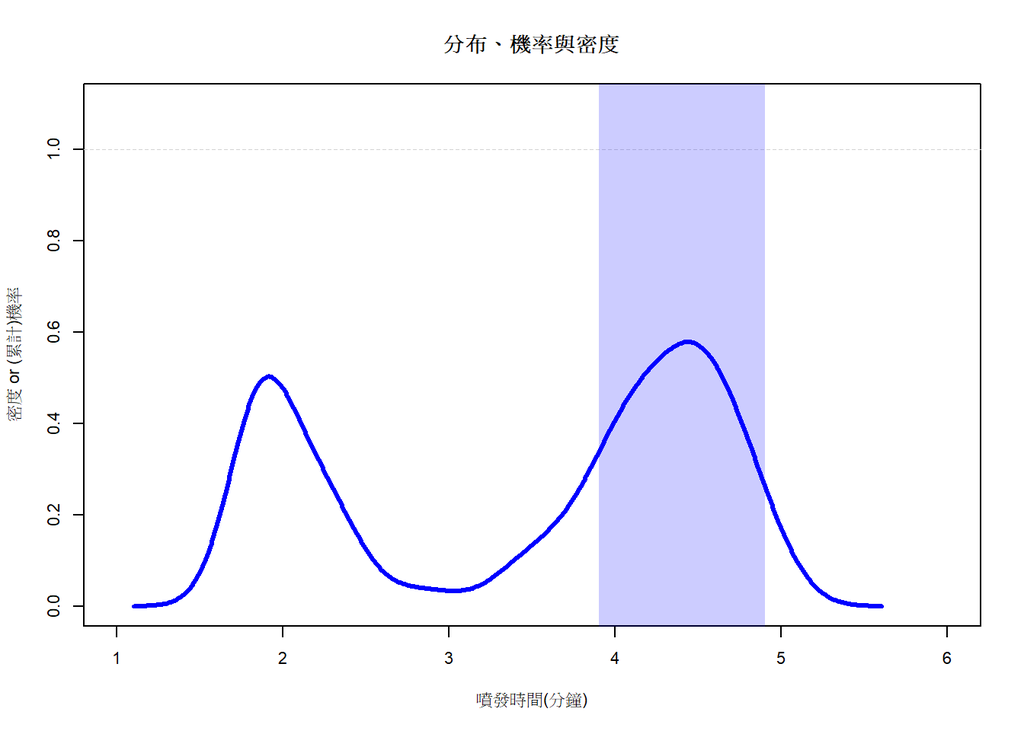

```r
D = faithful$eruptions
plot(0,0,xlim=c(1,6),ylim=c(0,1.1),xlab="噴發時間(分鐘)", ylab="密度 or (累計)機率", main="分布、機率與密度")
abline(h=1, col='lightgray', lwd=0.25, lty=2)
DEN = density(D, adjust = 0.5)
lines(DEN, col='blue', lwd=3)
rect(3.9,-0.1,4.9,1.2,col= rgb(0,0,1,alpha=0.2),border=NA)
```

```r
Adjust = 0.5
DEN = density(D, adjust = Adjust)
PDF = approxfun(DEN$x, DEN$y, yleft=0, yright=0)
(P = integrate(PDF, 3.9, 4.9)$value)
```

```
[1] 0.4766
```

■ 你設在這個區間的話，參加這個賭局的期望值是？  
Ans:(1-0.4766)x(-30)+0.4766x70=17.66

假如賭場老闆從零開始把每10秒鐘設為一個區間，每個區間的賭金是五塊錢 …

```r
# Read data
W = faithful$eruptions
summary(W)
```

```
   Min. 1st Qu.  Median    Mean 3rd Qu.    Max.
   1.60    2.16    4.00    3.49    4.45    5.10
```

```r
# Smooth PDF
Adjust = 0.5
DEN = density(W, adjust = Adjust)

# Smooth CDF
PDF = approxfun(DEN$x, DEN$y, yleft = 0, yright = 0)

#改為10秒一個區間
bk = seq(1, 6, 1/6)

#cbk為30個區間的累積機率
cbk = sapply(bk, function(bk) integrate(PDF, -Inf, bk)$value)

#鄰近區間的累積機率相扣，得出該區間的發生機率
p = cbk - c(0, cbk[1:(length(bk)-1)])

#payoff為期望值
payoff = 100 * p - 5

#組成dataframe
df = data.frame(bk, cbk, p, payoff)

#依payoff由大到小去排序應該下注的區間
df = df[order(-df$payoff),]

#csum為累積的期望值
df$csum = cumsum(df$payoff)

#期望值>0，四捨五入小數點第三位
round(df[df$payoff > 0,], 3)
```

```
      bk   cbk     p payoff   csum
22 4.500 0.778 0.096  4.576  4.576
23 4.667 0.867 0.089  3.938  8.514
21 4.333 0.682 0.089  3.932 12.446
7  2.000 0.179 0.082  3.226 15.672
20 4.167 0.593 0.077  2.652 18.325
8  2.167 0.249 0.070  1.967 20.292
24 4.833 0.936 0.068  1.844 22.135
6  1.833 0.097 0.064  1.366 23.502
19 4.000 0.516 0.058  0.836 24.338
```

將獲利的期望值和賭金的比值稱為「期望投資報酬率」 …  
■ 「最大期望投資報酬率」和「最大期望報酬」的投資策略是一樣的嗎？  
Ans:不一樣。  
最大期望投資報酬率是:每投入一塊錢所能獲得的利潤；  
最大期望報酬:所有利潤的加總  
■ 你認為哪一個策略目標比較好呢？ 為什麼？  
Ans:最大期望投資報酬率。能看現有成本推算利潤。